# Study of the human fecal matter pollution of northern Sydney beaches by measuring enterococci bacterial populations.

## 2.2 Research Question 1

Can water levels in Sydney’s Northern Beaches be classified as safe (less than 40 cfu of enterococci) in summer (December - January). Which ones are the top and least safest for swimmers?

### 2.2.1 Working

It would be better to divide the table for each Summer month and then sort them to find the highest values:

#### 2.2.1.1 December

```r
data_december = data.frame(data$Site[data$Month == "December"], data$Enterococci..cfu.100ml. [data$Month == "December"])
```

Mean:

```r
mean(data_december$data.Enterococci..cfu.100ml..data.Month.....December..)
```

```
## [1] 6.784091
```

SD:

```r
sd(data_december$data.Enterococci..cfu.100ml..data.Month.....December..)
```

```
## [1] 12.67766
```

Accounting for the high SD, it is best to look at individual beaches which contributed highly to the SD as outliers by using a graph plot.

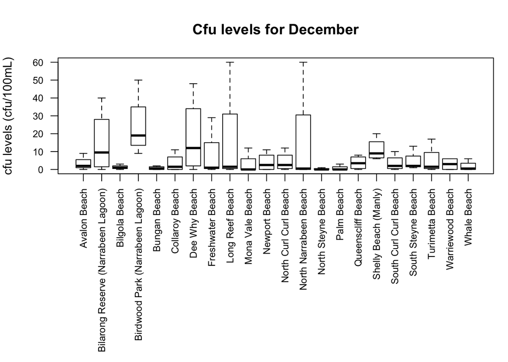

```r
par(mar = c(13,4,4,1))
plot(data_december,las=2, ylab = "cfu levels (cfu/100mL)", xlab = "", cex.axis=0.8, main = "Cfu levels for December")
```

#### 2.2.1.2 January

```r
data_january = data.frame(data$Site[data$Month == "January"], data$Enterococci..cfu.100ml. [data$Month == "January"])
```

Mean:

```r
mean(data_january$data.Enterococci..cfu.100ml..data.Month.....January..)
```

```
## [1] 107.4273
```

SD:

```r
sd(data_january$data.Enterococci..cfu.100ml..data.Month.....January..)
```

```
## [1] 413.91
```

Plot:

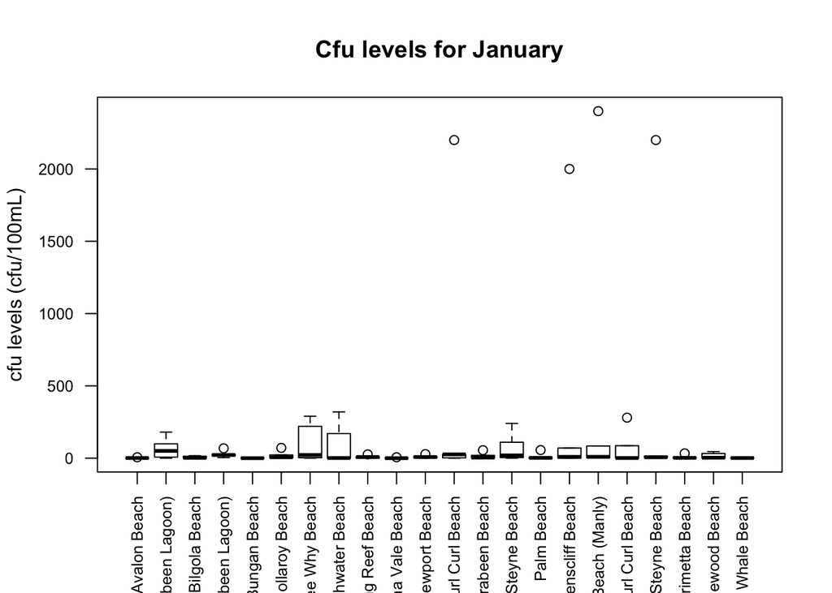

```r
plot(data_january,las=2, ylab = "cfu levels (cfu/100mL)", xlab = "", cex.axis=0.8, main = "Cfu levels for January")
```

Plot without outliers:

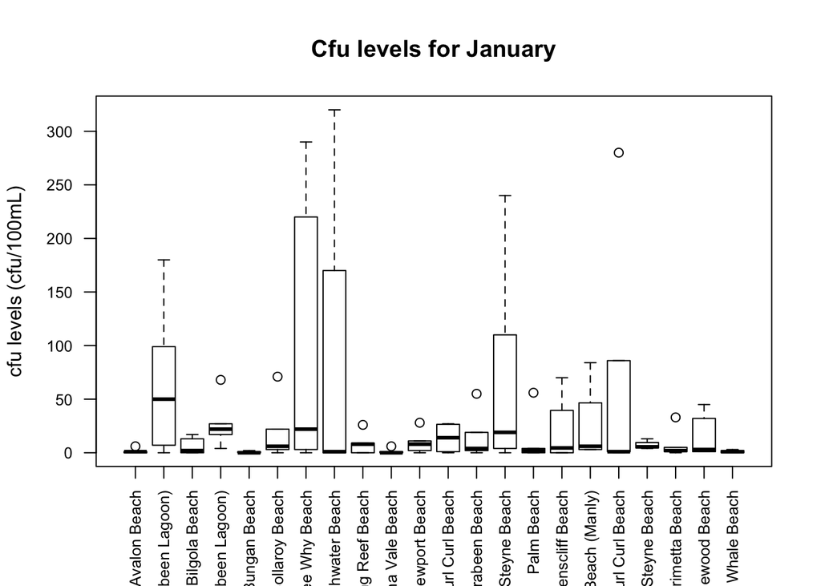

```r
data_january1 = data.frame(data_january$data.Site.data.Month.....January..[data_january$data.Enterococci..cfu.100ml..data.Month.....January..<2000], data_january$data.Enterococci..cfu.100ml..data.Month.....January..[data_january$data.Enterococci..cfu.100ml..data.Month.....January..<2000])
plot(data_january1,las=2, ylab = "cfu levels (cfu/100mL)", xlab = "", cex.axis=0.8, main = "Cfu levels for January")
```

#### 2.2.1.3 February

```r
data_february = data.frame(data$Site[data$Month == "February"], data$Enterococci..cfu.100ml.[data$Month=="February"])
```

Mean:

```r
mean(data_february$data.Enterococci..cfu.100ml..data.Month.....February..)
```

```
## [1] 11.11818
```

SD:

```r
sd(data_february$data.Enterococci..cfu.100ml..data.Month.....February..)
```

```
## [1] 27.18868
```

Plot:

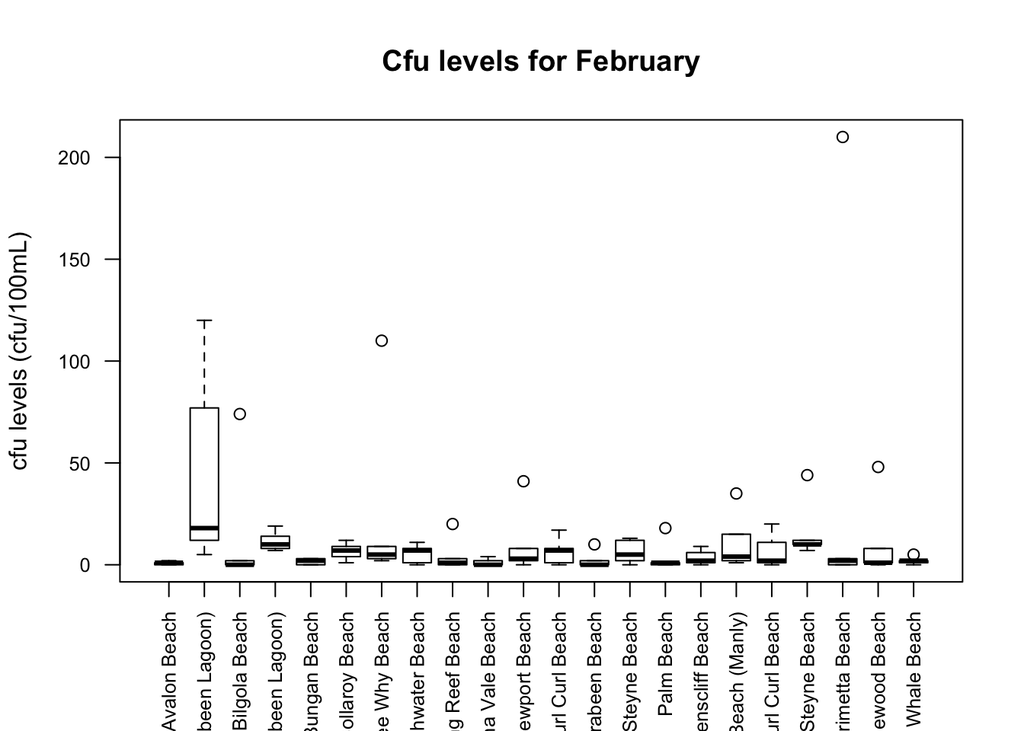

```r
plot(data_february,las=2, ylab = "cfu levels (cfu/100mL)", xlab = "", cex.axis=0.8, main = "Cfu levels for February")
```

### 2.2.2 Conclusion

January:

It was quite unclear from the plot with many outliers, which ones were the safest. However, after making another graph with the outliers removed, it became clearer as to which beaches had the highest levels of cfu. They included Bilarong Reserve (Narrabeen Lagoon), Dee Why Beach, Freshwater Beach, North Steyne Beach and South Curl Curl Beach. The safest included Avalon Beach, Bungan Beach, Long Reef Beach, Mona Vale Beach, Palm Beach, South Steyne Beach and Whale Beach.

February:

In February, only Bilarong Reserve (Narrabeen Lagoon) seemed to have increased cfu levels. While on the other hand, many of the beaches showed very low cfu levels excluding some beaches on certain days. For example, Bilgola Beach, Dee Why Beach, Long Reef Beach and Turimetta Beach.

Beaches to avoid: Bilarong Reserve (Narrabeen Lagoon) and Dee Why Beach.

Safest beaches: Bungan Beach, Palm Beach, Avalon Beach, Whale Beach and Bilgola Beaches.

## 2.3 Research Question 2

Do Enterococci bacteria thrive more in summer than in winter?

### 2.3.1 Working

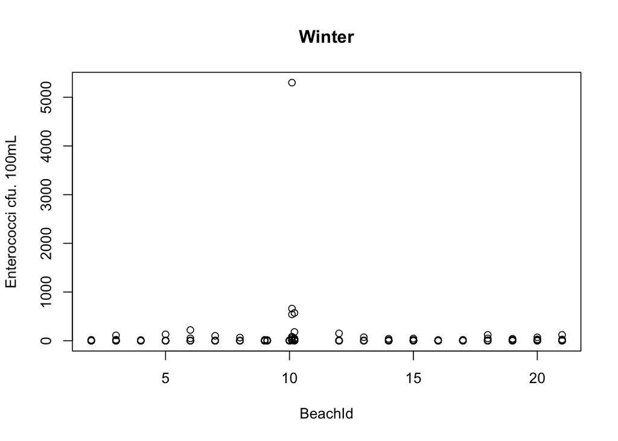

```r
Winter <- data[data$Month=="June" | data$Month=="July" | data$Month=="August",]
plot(Winter$BeachId,Winter$Enterococci..cfu.100ml., xlab = "BeachId", ylab = "Enterococci cfu. 100mL", main = "Winter")
```

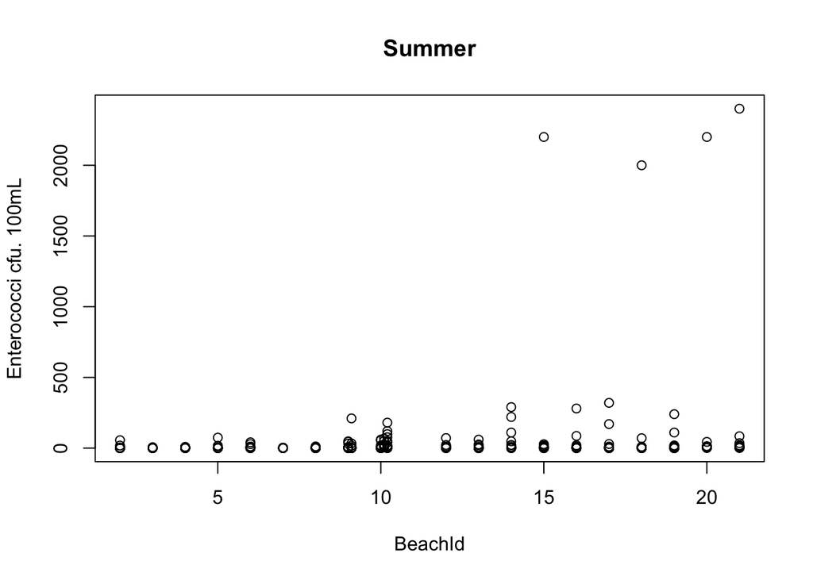

```r
Summer <- data[data$Month=="December" | data$Month=="January" | data$Month=="February",]
plot(Summer$BeachId,Summer$Enterococci..cfu.100ml., xlab = "BeachId", ylab = "Enterococci cfu. 100mL", main = "Summer")
```

Mean of Enterococci concentration during Winter (m1):

```r
m1 <- mean(Winter$Enterococci..cfu.100ml.)
m1
```

```
## [1] 31.52922
```

Mean of Enterococci concentration during Summer (m2):

```r
m2 <- mean(Summer$Enterococci..cfu.100ml.)
m2
```

```
## [1] 44.27597
```

```r
seasondiff <- m1 - m2
```

Standard deviation of concentration during Winter (sd1):

```r
sd1 <- sd(Winter$Enterococci..cfu.100ml.)
sd1
```

```
## [1] 307.6703
```

Standard deviation of concentration during Summer (sd2):

```r
sd2 <- sd(Summer$Enterococci..cfu.100ml.)
sd2
```

```
## [1] 251.7168
```

Length of winter (n1):

```r
n1 <- length(Winter$Enterococci..cfu.100ml.)
n1
```

```
## [1] 308
```

Length of summer (n2):

```r
n2 <- length(Summer$Enterococci..cfu.100ml.)
n2
```

```
## [1] 308
```

sdp2:

```r
sdp2 = ((n1 - 1) * sd1^2 + (n2 - 1) * sd2^2)/(n1 + n2 - 2)
sdp2
```

```
## [1] 79011.16
```

Standard error:

```r
se = sqrt(sdp2 * (1/n1 + 1/n2))
se
```

```
## [1] 22.65082
```

TestStat:

```r
TestStat = (m1 - m2 - 0)/se
TestStat
```

```
## [1] -0.5627503
```

PValue:

```r
Pvalue = pt(abs(TestStat), n1 + n2 - 2, lower.tail = F)
Pvalue
```

```
## [1] 0.2869052
```

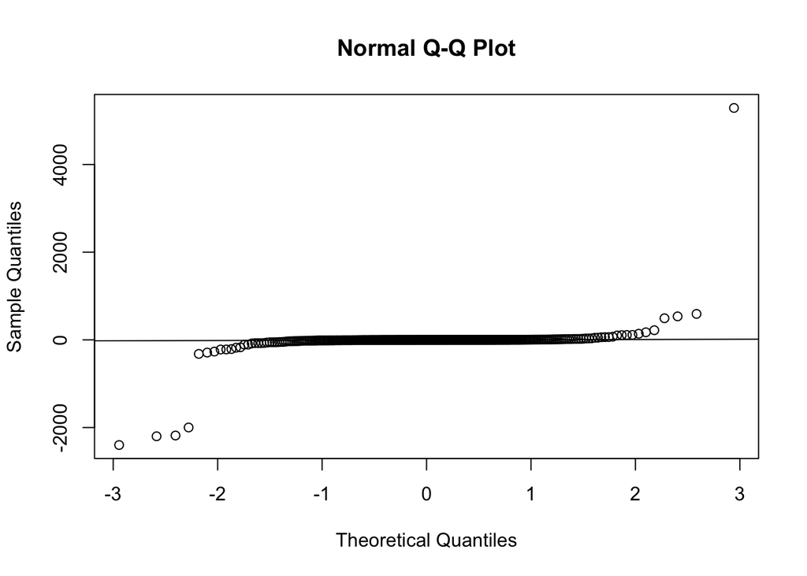

```r
sdiff = Winter$Enterococci..cfu.100ml. - Summer$Enterococci..cfu.100ml.

qqnorm(sdiff)
qqline(sdiff)
```

Shapiro-Wilk normality test:

```r
shapiro.test(sdiff)
```

```
##
##  Shapiro-Wilk normality test
##
## data:  sdiff
## W = 0.18393, p-value < 2.2e-16
```

Q-Q plot line does not show a reasonable straight line because there are many outliers, hence normality assumption may not be met. Shapiro Wilk test gives an extremely small value, which means that the data does not follow a normal distribution.

Therefore, Z test and T test results should be taken with caution.

#### 2.3.1.1 Hypothesis Testing

Hypothesis H0 : There is no difference: m1=m2 H1 : There is a difference: m1<m2

Test-statistic = observed test statistic is -0.5627503 P-value = 0.2869052

### 2.3.2 Conclusion

To test the hypothesis that there was a relationship between the seasons and the cfu levels in the different beaches, we ran a Test statistic, observing a value of -0.5627503, and a P-value of 0.2869052. We therefore found there was no strong relationship between the seasons temperatures and the cfu levels in the different beaches. The sea temperature of sydney beaches varies between 18oC at the lowest in winter, and 24oC at the highest in summer. (Weather in sydney, 2019) We found that the rate of reproduction of the bacteria remains roughly constant over that temperature range, therefore the results obtained were in line with expected results from our research. Boehm and Sassoubre, 2014 We found that in summer, we had many outliers in the cfu levels of different beaches on different days. This higher number of outliers could be explained by the increase in rainfall in summer. According to our research, rainfall leads to higher cfu levels in the beaches due to the release of sewage.

# 3 References

Survival of enteric bacteria in seawater. Rosen Y, Belkin S, FEMS Microbiology Reviews, Volume 25, Issue 5, December 2001, Pages 513–529. Published: 01 December 2001. https://academic.oup.com/femsre/article/25/5/513/499961

Monitoring beach water quality. 2019. NSW Government Office for Environment and Heritage. Viewed 1 November 2019

Enterococci as indicators of environmental fecal contamination. Boehm, A.B, Sussoubre, L.M. 2014. Viewed 1 November 2019. https://www.ncbi.nlm.nih.gov/books/NBK190421/

Weather in sydney, 2019. Australia.com viewed 1 November 2019. https://www.australia.com/en/facts-and-planning/weather-in-australia/sydney-weather.html